# Project 1: Investigating the Dataset : noshowappointments

## Sixth question to answer

> 1. Does the abscence dependent on the type of the disease is it an emergency or not : (Hipertension, Diabetes , Alcoholism, Handcap)

To go back to the questions section click here

I would like to create a new column having all the diseases for each patient

```python
#I will make some modifications to the columns of the diseases replacing the 1 with the name of the disease
#to not repeat the same code I have create a function to edit the columns easily
def replace_col(disease,from_value=1,to_value='optional'):
    global df
    if to_value == 'optional':
        df[disease].replace({from_value:disease}, inplace=True)
        return df[disease]
    else :
        df[disease].replace({from_value:to_value}, inplace=True)
        return df[disease]
#I made the if statement because I wasn't able to write: def replace_col(disease,from_value=1,to_value=disease):
#so I used this method
```

```python
#replacing the 1 with the name of the disease in the 3 first lines
replace_col('hipertension')
replace_col("diabetes")
replace_col("alcoholism")
#replacing the 1 with the exact level of the disease in the following 3 lines
replace_col('handcap',1,"handicap level 1")
replace_col('handcap',2,"handicap level 2")
replace_col('handcap',3,"handicap level 3")
replace_col('handcap',4,"handicap level 4")
#replacing the 0 with not sick to make it easier to read when plotting
replace_col('hipertension',0,'Not sick')
replace_col("diabetes",0,'Not sick')
replace_col("alcoholism",0,'Not sick')
replace_col('handcap',0,"Not sick")
```

```
0         Not sick
1         Not sick
2         Not sick
3         Not sick
4         Not sick
            ...
110522    Not sick
110523    Not sick
110524    Not sick
110525    Not sick
110526    Not sick
Name: handcap, Length: 110527, dtype: object
```

```python
#checking the results
print(df['handcap'].unique())
```

```
['Not sick' 'handicap level 1' 'handicap level 2' 'handicap level 3'
 'handicap level 4']
```

```python
#checking the results
print(df['hipertension'].unique())
```

```
['hipertension' 'Not sick']
```

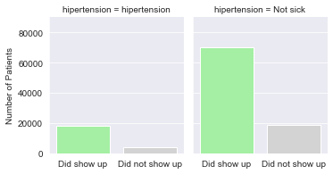

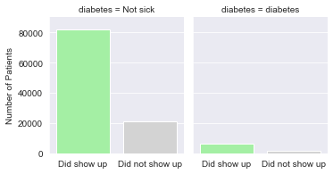

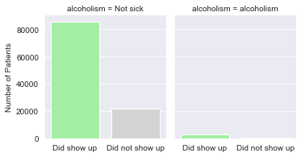

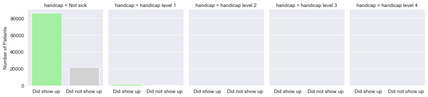

```python
#ploting the graphs using the previsou function: plot_sidebyside(col_name,top_y_lim, axis_label="Number of Patients")
plot_sidebyside('hipertension',90000)
plot_sidebyside('diabetes',90000)
plot_sidebyside('alcoholism',90000)
plot_sidebyside('handcap',90000)
```

In all the diseases the number of patient who are not sick and do show up is bigger than the number of patients who are sick and they show-up

Let's look at the proportions now

First, I will see if a disease has a higher show up rate than another

```
disease =  hipertension
```

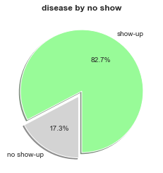

```
disease =  diabetes
```

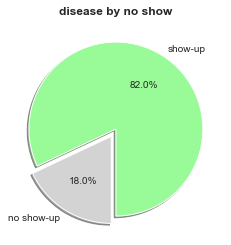

```
disease =  alcoholism
```

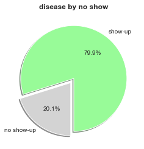

```
disease =  handcap
```

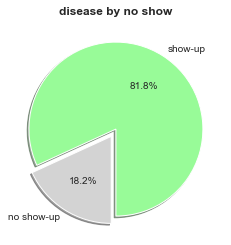

```python
#creating new df for each disease
df_hipertension = df.query('hipertension == "hipertension"')
df_diabetes =df.query('diabetes == "diabetes"')
df_alcoholism =df.query('alcoholism == "alcoholism"')
df_handcap =df.query("handcap != 'Not sick'")
for i,j in [[df_hipertension,'hipertension'],[df_diabetes,"diabetes"],[df_alcoholism,'alcoholism'],[df_handcap,'handcap']]:
    print("disease = " ,j)
    pie_chart('disease by no show', i["no_show"].value_counts())
```

All the diseases have the same percentages of showing up (approximatly 80%) and the same percentages of not showing up (approximately 20%)

Let's now look if people who are not suffering from a specific disease tend to show up more or not

```python
df_no_hipertension =df.query('hipertension != "hipertension"')
df_no_diabetes =df.query('diabetes != "diabetes"')
df_no_alcoholism =df.query('alcoholism != "alcoholism"')
df_no_handcap =df.query("handcap == 'Not sick'")
```

```
Not sick with  hipertension
```

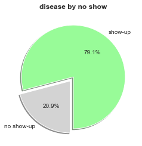

```
Not sick with  diabetes
```

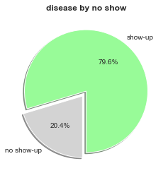

```
Not sick with  alcoholism
```

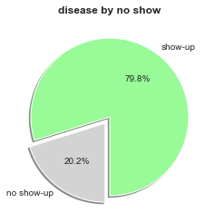

```
Not sick with  handcap
```

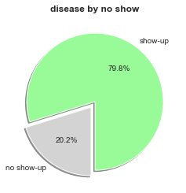

```python
for i,j in [[df_no_hipertension,'hipertension'],[df_no_diabetes,"diabetes"],[df_no_alcoholism,'alcoholism'],[df_no_handcap,'handcap']]:
    print("Not sick with " ,j)
    pie_chart('disease by no show', i["no_show"].value_counts())
```

For people who are not suffering from diseases the rate of showing up and not shoowing up is respectively 80% and 20%

## Seventh question to answer

> Is it that people forget about their appointment?

To go back to the questions section click here

```python
yes_sms= df.query('sms_received==1')
no_sms= df.query('sms_received==0')
```

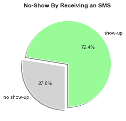

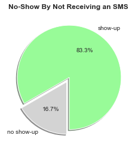

```python
pie_chart('No-Show By Receiving an SMS ',yes_sms['no_show'].value_counts())
pie_chart('No-Show By Not Receiving an SMS ',no_sms['no_show'].value_counts())
```

Patients who received an SMS reminder, their show up rate is 72.4%  
Patient who did not receive an sms have a show up rate of 83.3%

## Conclusions

### After answering question 1

(Is the absence higher in one gender more than another? )

#### We conclude that there is no specific gender that misses the appointement more than the other

### After answering question 2

( Is the absence higher in older age than younger ones? ) We can conclude that young people tend to show up less than old people

### After answering question 3

(Is showing up higher in a specific month more than another? )

#### We can conclude that the regardeless of the appointement month the abscence or presence rate to an appointement is constant

### After answering Additional question

( Is showing up higher when schedule date and appointment date are the same? )

#### -->We can conclude that when the appointement date is the same as the scheduling date patient tend to show up more as compared to patients who have their appointement date different from the shceduling date

Is it that people forget about their appointement if it is not in the same date?

we can not know through this data alone we need further investigation and more data

### After answering question 4

(Is the absence higher for specific neighborhoods than others? )  
(limitation) We can further investigate what can be the causes of this lower percentages of showing-up but

Seeing how the vast majority of neighborhoods having approximetly the same percentages of presence and abscence

#### We can conclude that people tend to show up or not to their appointement independently of the neighberhood

### After answering question 5

(Do people having scholarship attend more to their consultation because it is free )  
(limitation) we can not conclude that having no scholarship makes the patient wants to attend more. Instead

#### -->We can conclude that having a scholarship does not influence the show up rate to become higher

### After answering question 6

(Does the absence dependent on the type of the disease is it an emergency or not : (Hipertension, Diabetes , Alcoholism, Handcap) )  
Percentages of not suffering or suffering from a specific disease by the show up rate are approximately the same

### We can conclude that showing up does not depend of a specific disease more than another

#### We can conclude that showing up does not depend of suffering or not from a specific disease

### After answering question 7

(Do people receiving SMS tend to show up more than others? )  
It is quite clear that even though patients received an SMS reminder but their show up rate (72.4%) is less than the show up rate of patients who did not receive an sms (83.3%) (limitation)

#### -->But we can not concluding that showing up does depend of suffering not sending a message we need more information to understand this relationship